# 2022.03.Workbook

28 July, 2023

## Purpose

This is the motivation (from Jacobson et al 2016): “We quantified water quality effects of land use by calculating the relative amount of disturbed land within a watershed. A simple, yet direct watershed disturbance variable (percentage of urban, agriculture, and mining land uses in a catchment) was developed by Cross and Jacobson (2013) using National Land Cover Database 2001 land use GIS data. The percentage land use disturbance variable was significant in models predicting total phosphorus concentrations in Minnesota lakes (Cross and Jacobson 2013). Catchments with undisturbed land uses lie primarily in the Northern Forests ecoregion (CEC 1997; Level 1) and generally provide good water quality to lakes and streams in that region (Figure 5). Catchments within the agricultural Great Plains ecoregion have the highest disturbed land uses and appreciably poorer water quality (Heiskary et al. 1987; Ramstack et al. 2004). Catchments in the transition from forest to prairie in the Eastern Temperate Forests ecoregion have a wide range of disturbance values. Cross and Jacobson (2013) noted that phosphorus concentrations generally become elevated when watershed land use disturbance reached 25% and greatly increased when land use disturbances exceeded 60%. These disturbance values set the foundation for the identification of appropriate management strategies for water quality in lakes under this framework. Lakes with relatively undisturbed watersheds need protection, whereas lakes with heavily disturbed watersheds need restoration.”

coding reference: https://rdrr.io/cran/mgcViz/man/plot.gamViz.html

GAM reference: http://r.qcbs.ca/workshop08/book-en/gam-with-interaction-terms.html

## Correlations

Parameters:

1. Median, natural log, epilimnetic, Total Phosphorus
2. W:L (although as noted, this is % open water which isn’t truely W:L)
3. Depth (when available)
4. NLCD watershed Disturbance (2016 NLCD: VALUE_21+VALUE_22+VALUE_23+VALUE_24+VALUE_82+VALUE_81 –> #note that the 2013 article did not use 81 (pasture hay) but we include it)
5. Soil with high rate of water transmission (group A): https://www.arcgis.com/home/item.html?id=56d328b000274fcfb17864a7bb0ccaff

“Soils with parent material formed by glacial outwash are usually well drained. We used maps developed by Cum- mins and Grigal (1981) and digitized by MNDNR (2011) to identify areas with glacial outwash, which we summarized as a percent of the total watershed for each lake. We summarized land use categories assigned by the National Land Cover Database (Homer et al. 2004) as a percent of the total watershed area for each lake.” - Jacobson 2013

We used group A as an alternative to this parameter used by Jacobson.

6. NLCD disturbance in the 100m buffer (2019 NLCD)
7. Septic density within the 200m buffer

The KT Correlations of these parameters

| pair1 | depth | DISTURBANCE | DISTURBANCE100m | phosphorus | septic | well_drained_soils | WLarea |
| --- | --- | --- | --- | --- | --- | --- | --- |
| depth | NA | -0.062 | 0.000 | -0.395 | 0.257 | 0.000 | -0.145 |
| DISTURBANCE | -0.062 | NA | 0.712 | 0.411 | 0.208 | 0.000 | 0.074 |
| DISTURBANCE100m | 0.000 | 0.712 | NA | 0.323 | 0.248 | -0.076 | 0.000 |
| phosphorus | -0.395 | 0.411 | 0.323 | NA | 0.000 | 0.000 | 0.178 |
| septic | 0.257 | 0.208 | 0.248 | 0.000 | NA | 0.000 | 0.107 |
| well_drained_soils | 0.000 | 0.000 | -0.076 | 0.000 | 0.000 | NA | 0.000 |
| WLarea | -0.145 | 0.074 | 0.000 | 0.178 | 0.107 | 0.000 | NA |

Conclusions:

1. Watershed disturbance has a greater correlation with phosphorus than the disturbance in the 100m buffer.
2. Septic and well drained Soils are not correlated with phosphorus so I removed them from the model

## GAM models

documentation: https://cran.r-project.org/web/packages/mgcv/mgcv.pdf

reference: https://www.mainard.co.uk/post/why-mgcv-is-awesome/#generalized-additive-models-gams

from Jacobson et al 2013

“For GAM calculations we used the mgcv package, which auto- matically selects degrees of freedom for each smooth term in the model by minimizing the generalized cross validation score. The GAM models were run using a Gaussian distri- bution and default settings.We used the GAM plot function to examine the contribution of each component’s smooth function on TP and to evaluate the statistical significance of each smooth term based on the null hypotheses that each smooth term is zero, similar to probability values of terms that would be calculated in a general linear model.”

Observations:

The order of the anlyses below are necessary but confusing to understand the overall conclusions so I have summarized them here as well:

0. Explanations of abbreviations

All separated - a gam model with all parameters included

No 100m - a gam model with 100m buffer removed

No dist - a gam model with the 100m buffer and the watershed disturbance removed

Only_distdepth - a gam model with only disturbance and depth (as these were the most significant parameters)

Interact - a gam model using the interaction of the disturbance and depth

1111111.View the AIC scores first (last in the list of analyses below).

Conclusion: The model that performed best (has the lowest AIC score) was the model with only disturbance and depth.

1. GAM model - all parameters: Conclusions:

NOTE1: The influence of 100m disturbance and soil draining is negative which is contradictory to what we’d expect (correlation is positive). see this page which talks about this supressor effect: https://www.researchgate.net/post/What-does-it-indicating-If-there-is-positive-correlation-but-negative-regression-coefficient

NOTE2: 100m disturbance did not significantly contribute to the model

NOTE3: The concurvity of both disturbance values is over 0.8 as well. This implies that they are too similar to both include in the model.

NOTE5: as a final test, I tried removing the 100m buffer area from the overal disturbance parameter and the results were still as notes 1-4 above

THEREFORE: I am removing 100m disturbance

1. GAM model - no watershed disturbance.

Conclusion: The 100m disturbance is significant when we remove the influence of the watershed wide disturbance. Therefore, shoreline projects are valuable to reduce run off

1. Gam Model - only watershed disturbance and depth. Conclusions:

The disturbance and depth model was the GAM model that performed best (lowest AIC)

1. Interaction

Just a really cool plot but the AIC score is high so really can’t use it.

### GAM:all_parameters

```r
library(mgcv)
#GAM of all parameters
all_separated <- gam(phosphorus~s(DISTURBANCE)+s(DISTURBANCE100m)+s(depth)+s(WLarea), data=TP_matrix %>% filter(!is.na(depth)))
summary(all_separated)
```

```
##
## Family: gaussian
## Link function: identity
##
## Formula:
## phosphorus ~ s(DISTURBANCE) + s(DISTURBANCE100m) + s(depth) +
##     s(WLarea)
##
## Parametric coefficients:
##             Estimate Std. Error t value Pr(>|t|)
## (Intercept)   29.511      2.309   12.78   <2e-16 ***
## ---
## Signif. codes:  0 '***' 0.001 '**' 0.01 '*' 0.05 '.' 0.1 ' ' 1
##
## Approximate significance of smooth terms:
##                      edf Ref.df     F  p-value
## s(DISTURBANCE)     7.921  8.687 5.950 5.52e-07 ***
## s(DISTURBANCE100m) 1.000  1.000 1.618    0.204
## s(depth)           4.130  4.991 5.774 3.80e-05 ***
## s(WLarea)          1.000  1.000 0.192    0.661
## ---
## Signif. codes:  0 '***' 0.001 '**' 0.01 '*' 0.05 '.' 0.1 ' ' 1
##
## R-sq.(adj) =  0.199   Deviance explained = 22.3%
## GCV = 2609.8  Scale est. = 2527      n = 474
```

NOTE1: The influence of 100m disturbance and soil draining is negative which is contradictory to what we’d expect (correlation is positive). see this page which talks about this supressor effect: https://www.researchgate.net/post/What-does-it-indicating-If-there-is-positive-correlation-but-negative-regression-coefficient

NOTE2: 100m disturbance did not significantly contribute to the model

NOTE3: The concurvity of both disturbance values is over 0.8 as well. This implies that they are too similar to both include in the model.

NOTE5: as a final test, I tried removing the 100m buffer area from the overal disturbance parameter and the results were still as notes 1-4 above

THEREFORE: I am removing 100m disturbance

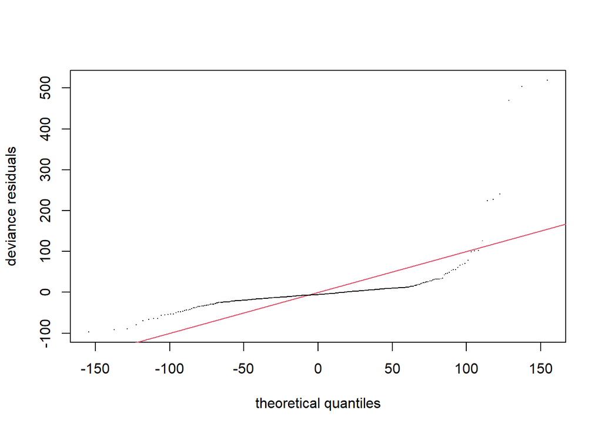

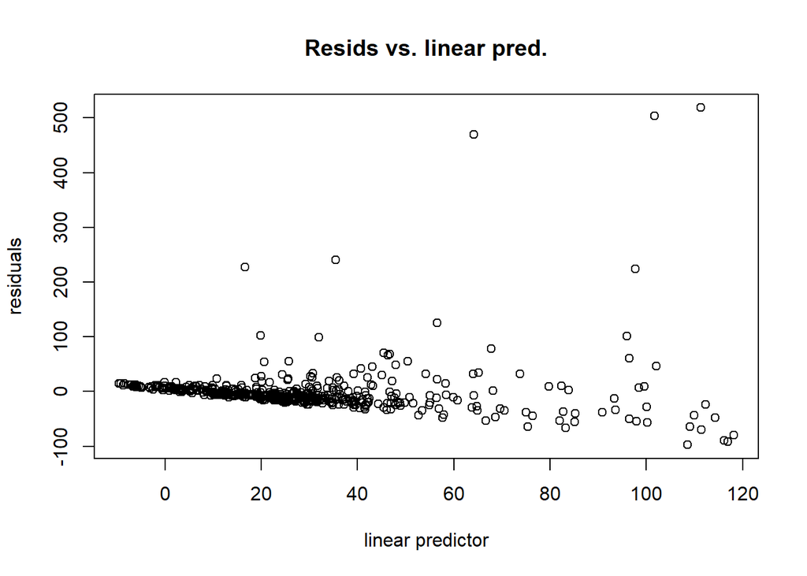

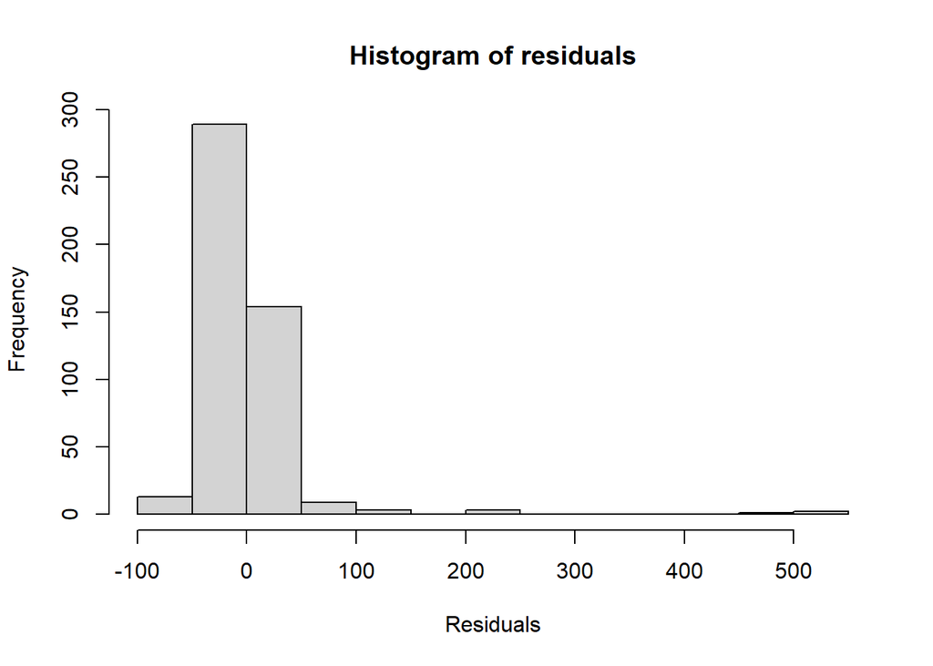

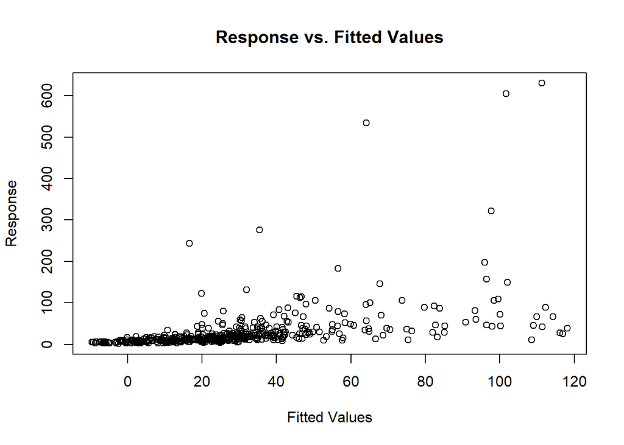

```
##
## Method: GCV   Optimizer: magic
## Smoothing parameter selection converged after 18 iterations.
## The RMS GCV score gradient at convergence was 0.0001433598 .
## The Hessian was positive definite.
## Model rank =  37 / 37
##
## Basis dimension (k) checking results. Low p-value (k-index<1) may
## indicate that k is too low, especially if edf is close to k'.
##
##                      k'  edf k-index p-value
## s(DISTURBANCE)     9.00 7.92    1.06    0.96
## s(DISTURBANCE100m) 9.00 1.00    1.05    0.90
## s(depth)           9.00 4.13    1.07    0.99
## s(WLarea)          9.00 1.00    1.05    0.93
```

```r
#GAM of only the significant parameters
#check that the k value isn't too low. none of them should be significant
gam.check(all_separated)
```

```r
#check that parameters aren't too similar (worst shouldn't be >0.5)
concurvity(all_separated, full = TRUE)
```

```
##                  para s(DISTURBANCE) s(DISTURBANCE100m)   s(depth)  s(WLarea)
## worst    2.916601e-22      0.8429944          0.8396120 0.19609263 0.26486660
## observed 2.916601e-22      0.6548898          0.7485591 0.17631516 0.05440201
## estimate 2.916601e-22      0.6744670          0.6336604 0.07801036 0.04611504
```

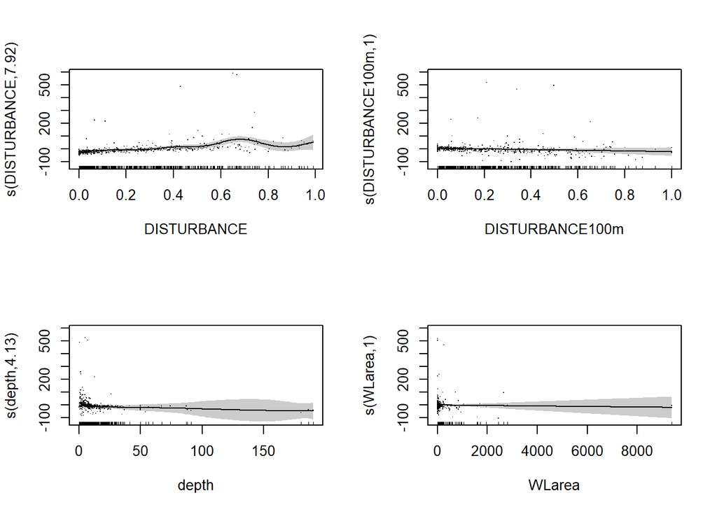

```r
#plotting
plot(all_separated,pages=1,all.terms=TRUE,residuals=TRUE,shade = TRUE)
```

[figure not shown]

```r
plot(all_separated,select=1,residuals = TRUE, pch=1, cex=1,
     seWithMean = TRUE,shade = TRUE,trans = function(x){exp(coef(all_separated)[1]+x)})
```

### GAM:no100m

```r
library(mgcv)
#GAM of all parameters
no100m <- gam(phosphorus~s(DISTURBANCE)+s(depth)+s(WLarea), data=TP_matrix %>% filter(!is.na(depth)))
summary(no100m)
```

```
##
## Family: gaussian
## Link function: identity
##
## Formula:
## phosphorus ~ s(DISTURBANCE) + s(depth) + s(WLarea)
##
## Parametric coefficients:
##             Estimate Std. Error t value Pr(>|t|)
## (Intercept)   29.511      2.309   12.78   <2e-16 ***
## ---
## Signif. codes:  0 '***' 0.001 '**' 0.01 '*' 0.05 '.' 0.1 ' ' 1
##
## Approximate significance of smooth terms:
##                  edf Ref.df     F  p-value
## s(DISTURBANCE) 8.051  8.755 9.259  < 2e-16 ***
## s(depth)       4.174  5.045 5.903 2.61e-05 ***
## s(WLarea)      1.000  1.000 0.102    0.749
## ---
## Signif. codes:  0 '***' 0.001 '**' 0.01 '*' 0.05 '.' 0.1 ' ' 1
##
## R-sq.(adj) =  0.198   Deviance explained = 22.1%
## GCV = 2606.2  Scale est. = 2528      n = 474
```

```r
#GAM of only the significant parameters
#check that the k value isn't too low. none of them should be significant
# gam.check(no100m)
# #check that parameters aren't too similar (worst shouldn't be >0.5)
 concurvity(no100m, full = TRUE)
```

```
##                 para s(DISTURBANCE)   s(depth)  s(WLarea)
## worst    2.72022e-22      0.1749001 0.16228698 0.14455671
## observed 2.72022e-22      0.1203861 0.13504757 0.02981834
## estimate 2.72022e-22      0.1324390 0.06180146 0.02771183
```

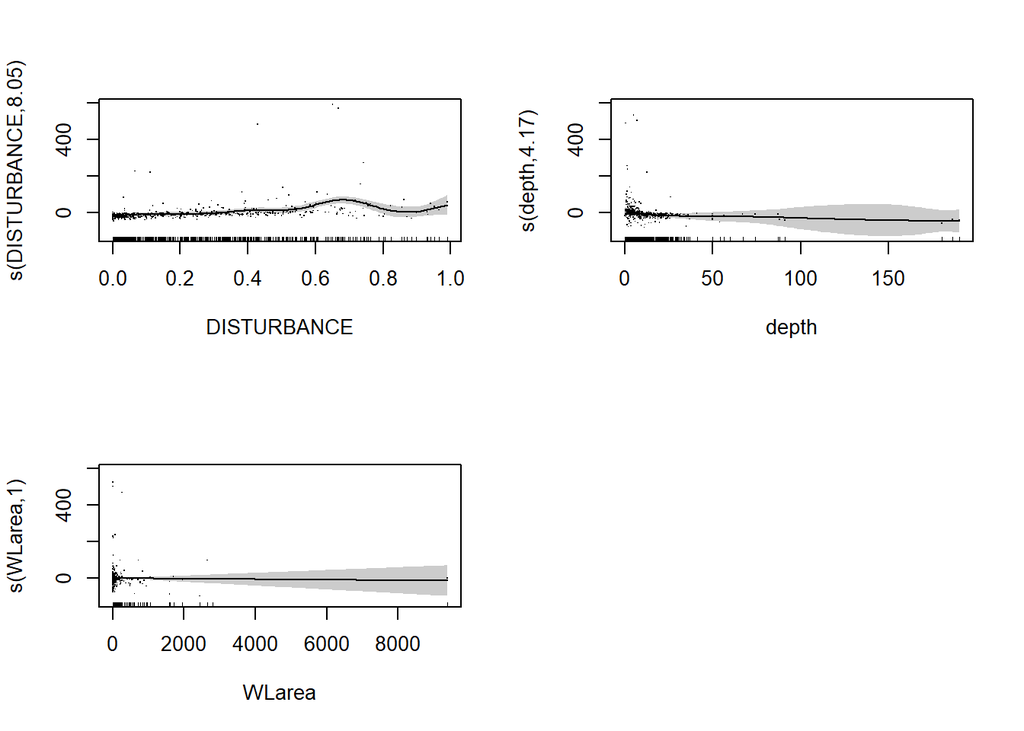

```r
#
#plotting
plot(no100m,pages=1,all.terms=TRUE,residuals=TRUE,shade = TRUE)
```

[figure not shown]

```r
plot(no100m,select=1,
     shade = TRUE,
     shift=coef(no100m)[1],
     trans=exp)
     abline(h=20, col="red")
     abline(v=.25, col="red")
```

### GAM:nodist

removed disturbance to see if 100mdisturbance model was more significant

```r
library(mgcv)
#GAM of all parameters
nodist <- gam(phosphorus~s(DISTURBANCE100m)+s(depth)+s(WLarea), data=TP_matrix %>% filter(!is.na(depth)))
summary(nodist)
```

```
##
## Family: gaussian
## Link function: identity
##
## Formula:
## phosphorus ~ s(DISTURBANCE100m) + s(depth) + s(WLarea)
##
## Parametric coefficients:
##             Estimate Std. Error t value Pr(>|t|)
## (Intercept)   29.511      2.412   12.24   <2e-16 ***
## ---
## Signif. codes:  0 '***' 0.001 '**' 0.01 '*' 0.05 '.' 0.1 ' ' 1
##
## Approximate significance of smooth terms:
##                      edf Ref.df      F  p-value
## s(DISTURBANCE100m) 1.555  1.933 13.988 2.29e-06 ***
## s(depth)           4.469  5.400  6.891 2.14e-06 ***
## s(WLarea)          1.000  1.000  0.053    0.817
## ---
## Signif. codes:  0 '***' 0.001 '**' 0.01 '*' 0.05 '.' 0.1 ' ' 1
##
## R-sq.(adj) =  0.126   Deviance explained = 13.9%
## GCV =   2804  Scale est. = 2756.5    n = 474
```

```r
#GAM of only the significant parameters
#check that the k value isn't too low. none of them should be significant
# gam.check(nodist)
# #check that parameters aren't too similar (worst shouldn't be >0.5)
 concurvity(nodist, full = TRUE)
```

```
##                  para s(DISTURBANCE100m)  s(depth)  s(WLarea)
## worst    2.641248e-22         0.18584038 0.1382710 0.19545158
## observed 2.641248e-22         0.05179087 0.1247013 0.03143731
## estimate 2.641248e-22         0.05968776 0.0396853 0.02529198
```

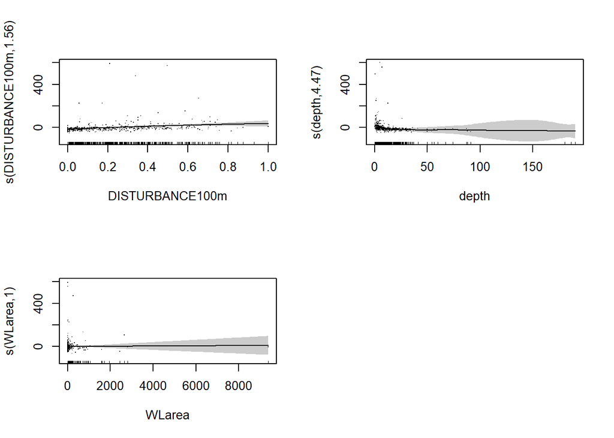

```r
#
#plotting
plot(nodist,pages=1,all.terms=TRUE,residuals=TRUE,shade = TRUE)
```

[figure not shown]

```r
plot(nodist,select=1,
     shade = TRUE,
     shift=coef(no100m)[1],
     trans=exp)
     abline(h=20, col="red")
     abline(v=.25, col="red")
```

### GAM:only_distdepth

```r
library(mgcv)
#GAM of all parameters
only_distdepth <- gam(phosphorus~s(DISTURBANCE)+s(depth), data=TP_matrix %>% filter(!is.na(depth)))
summary(only_distdepth)
```

```
##
## Family: gaussian
## Link function: identity
##
## Formula:
## phosphorus ~ s(DISTURBANCE) + s(depth)
##
## Parametric coefficients:
##             Estimate Std. Error t value Pr(>|t|)
## (Intercept)   29.511      2.308   12.79   <2e-16 ***
## ---
## Signif. codes:  0 '***' 0.001 '**' 0.01 '*' 0.05 '.' 0.1 ' ' 1
##
## Approximate significance of smooth terms:
##                  edf Ref.df     F  p-value
## s(DISTURBANCE) 8.002  8.736 9.291  < 2e-16 ***
## s(depth)       4.144  5.008 5.914 2.61e-05 ***
## ---
## Signif. codes:  0 '***' 0.001 '**' 0.01 '*' 0.05 '.' 0.1 ' ' 1
##
## R-sq.(adj) =    0.2   Deviance explained =   22%
## GCV = 2595.9  Scale est. = 2523.9    n = 474
```

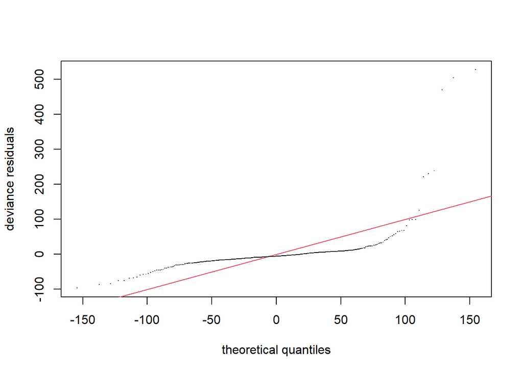

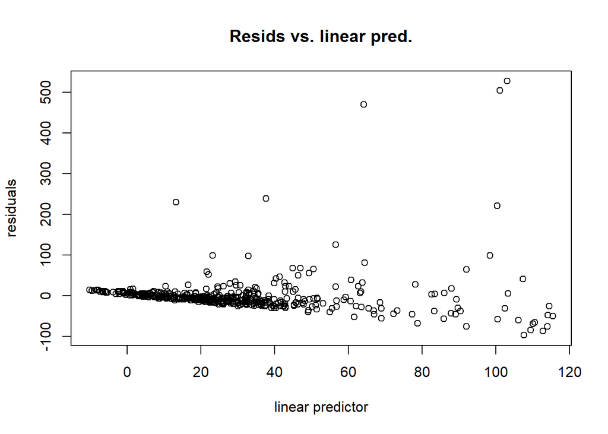

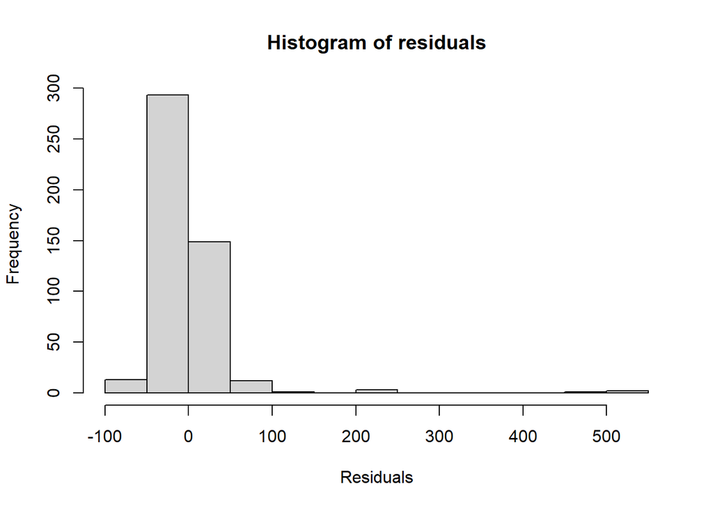

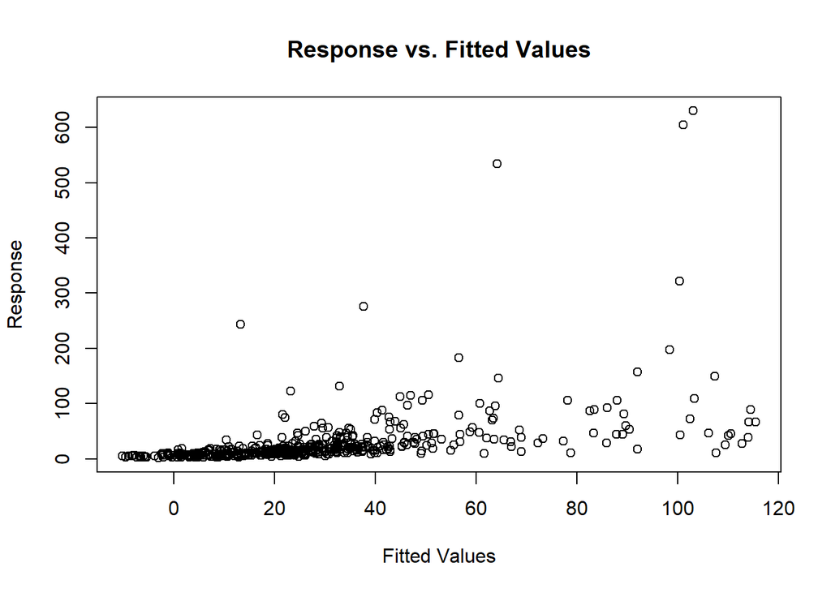

```
##
## Method: GCV   Optimizer: magic
## Smoothing parameter selection converged after 5 iterations.
## The RMS GCV score gradient at convergence was 0.001204637 .
## The Hessian was positive definite.
## Model rank =  19 / 19
##
## Basis dimension (k) checking results. Low p-value (k-index<1) may
## indicate that k is too low, especially if edf is close to k'.
##
##                  k'  edf k-index p-value
## s(DISTURBANCE) 9.00 8.00    1.07    0.97
## s(depth)       9.00 4.14    1.07    0.98
```

```r
#GAM of only the significant parameters
#check that the k value isn't too low. none of them should be significant
gam.check(only_distdepth)
```

```r
#check that parameters aren't too similar (worst shouldn't be >0.5)
concurvity(only_distdepth, full = TRUE)
```

```
##                  para s(DISTURBANCE)   s(depth)
## worst    2.097155e-23     0.11455287 0.11455287
## observed 2.097155e-23     0.06285218 0.08393555
## estimate 2.097155e-23     0.08136039 0.05306417
```

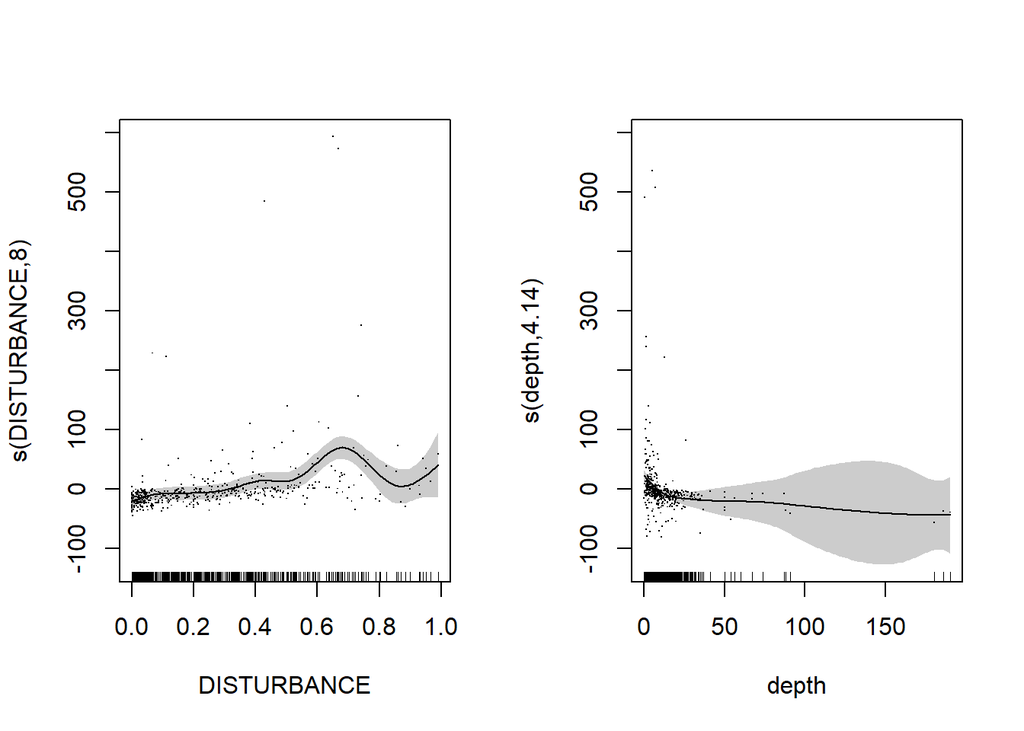

```r
#plotting
plot(only_distdepth,pages=1,all.terms=TRUE,residuals=TRUE,shade = TRUE)
```

[figure not shown]

```r
plot(only_distdepth,select=1,
     shade = TRUE,
     shift=coef(only_distdepth)[1],
     trans=exp)
     abline(h=20, col="red")
     abline(v=.25, col="red")

plot(only_distdepth,select=3,
     shade = TRUE,residuals=TRUE,
     shift=coef(only_distdepth)[1],
     trans=exp)
     abline(h=20, col="red")
```

### Now create a smoothed interactions plot between the most significant predictors depth and disturbance

```r
interact <- gam(phosphorus ~ s(DISTURBANCE,depth), data = TP_matrix %>% filter(!is.na(depth)), method = "REML")
summary(interact)
```

```
##
## Family: gaussian
## Link function: identity
##
## Formula:
## phosphorus ~ s(DISTURBANCE, depth)
##
## Parametric coefficients:
##             Estimate Std. Error t value Pr(>|t|)
## (Intercept)   29.511      2.352   12.55   <2e-16 ***
## ---
## Signif. codes:  0 '***' 0.001 '**' 0.01 '*' 0.05 '.' 0.1 ' ' 1
##
## Approximate significance of smooth terms:
##                        edf Ref.df     F p-value
## s(DISTURBANCE,depth) 4.974  6.213 15.76  <2e-16 ***
## ---
## Signif. codes:  0 '***' 0.001 '**' 0.01 '*' 0.05 '.' 0.1 ' ' 1
##
## R-sq.(adj) =  0.169   Deviance explained = 17.7%
## -REML =   2534  Scale est. = 2621.8    n = 474
```

```r
#GAM of only the significant parameters
#check that the k value isn't too low. none of them should be significant
#gam.check(interact)
#check that parameters aren't too similar (worst shouldn't be >0.5)
concurvity(interact, full = TRUE)
```

```
##                  para s(DISTURBANCE,depth)
## worst    3.674754e-21         3.674266e-21
## observed 3.674754e-21         1.388062e-28
## estimate 3.674754e-21         3.204698e-26
```

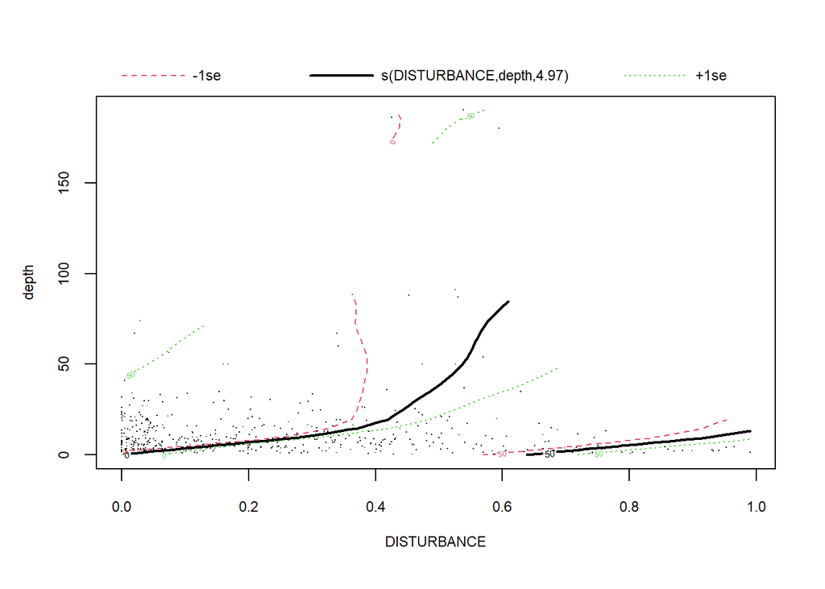

```r
plot(interact)
```

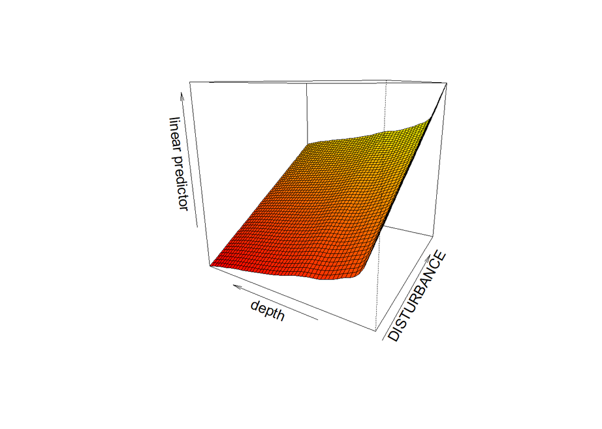

```r
library(mgcViz)
vis.gam(interact, view = c("DISTURBANCE", "depth"),
    theta = 300, n.grid = 50, lwd = 0.4)
```

### Now compare the best fit model of those generated above

lower aic are better

```r
AIC(all_separated,no100m,nodist,only_distdepth,interact)
```

```
##                       df      AIC
## all_separated  16.051147 5075.641
## no100m         15.225769 5075.044
## nodist          9.024341 5110.002
## only_distdepth 14.146521 5073.215
## interact        7.845027 5085.977
```

```r
AIC(all_separated,no100m,nodist,only_distdepth,interact)
```

[output not shown]